## Week 3

### Introduction

This weeks’ assignment focuses on the risk factors of high alcohol use among secondary school students in Portugal. I am using data collected from two schools in Portugal [(Cortez and Silva 2008)](https://archive.ics.uci.edu/ml/datasets/Student+Performance). The data includes information on weekly alcohol use, grades in Mathematics and Portuguese, as well as data on several background variables, such as parental education. I will start the analysis by graphically exploring the dataset, then move on to using logistic regression to describe relevant associations, and finally assess the model validity by cross-validation exercises.

```r
#Load packages
library(tidyverse)
library(GGally)
library(patchwork)
library(openxlsx)
#Read in the data
setwd("~/IODS-project/data")
alc_use <- read.xlsx("alc_use.xlsx")
```

### Exploratory analysis

I have modified the data by combining weekday and weekend alcohol use and constructed a binary variable indicating high alcohol use (average daily alcohol consumption > 2). Based on previous knowledge on the topic, I assume that males, students with less educated parents, students with problematic family relations and students going out a lot are likely to be at increased risk of high alcohol use.

First, let’s look at parental education. Education is available for both parents, but I will use information on either parent with the highest education.

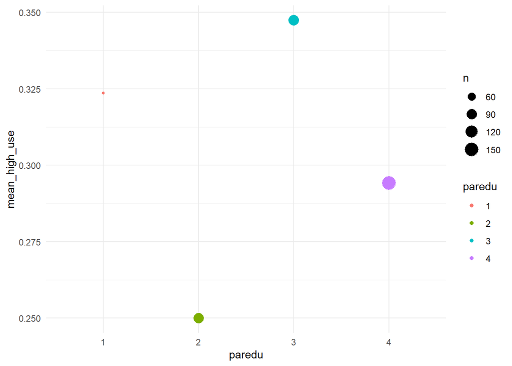

Means of high alcohol use by parental education. Size represents the number of observations

```r
#Generate variable paredu
#=highest education of either parent

alc_use$paredu <-
  ifelse(alc_use$Fedu>alc_use$Medu,
         alc_use$Fedu,alc_use$Medu)

#Modify into factor
alc_use$paredu <-
  as.factor(alc_use$paredu)

#Plot means of high use
#by parental education

alc_use %>%
  group_by(paredu) %>%
  summarise(mean_high_use=mean(high_use),
            n=n())%>%
  ggplot(aes(x=paredu,
             y=mean_high_use,
             size=n,
             col=paredu)) +
  geom_point() +
  theme_minimal()
```

```r
prop.table(table(alc_use$paredu))
```

```
##
##          1          2          3          4
## 0.09189189 0.23783784 0.25675676 0.41351351
```

```r
prop.table(table(alc_use$paredu,alc_use$high_use),1)
```

```
##
##         FALSE      TRUE
##   1 0.6764706 0.3235294
##   2 0.7500000 0.2500000
##   3 0.6526316 0.3473684
##   4 0.7058824 0.2941176
```

```r
chisq.test(alc_use$paredu,alc_use$high_use)
```

```
##
##  Pearson's Chi-squared test
##
## data:  alc_use$paredu and alc_use$high_use
## X-squared = 2.1775, df = 3, p-value = 0.5364
```

From the figure we see that there are no clear pattern between parental education and high alcohol use. The highest proportion of high alcohol use is at level 3, and lowest at level 2. The Chi-squared test also indicates that there is no statistically significant relationship between these two variables. Moreover, low parental education us relatively uncommon among the students (10%). Despite these findings, I will still hold on the education variable as it may be a possible confounder between the other variables and high alcohol use.

Second, I’ll look at the relationship between the quality of family relations and high alcohol use.

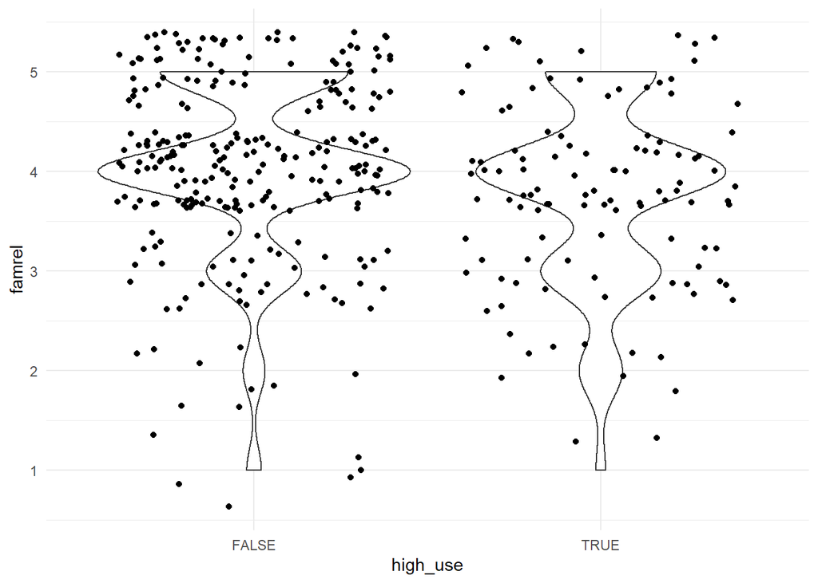

Quality of family relations and high alcohol consumption.Violin plot

```r
alc_use %>%
  ggplot(aes(x=high_use,
             y=famrel)) +
  geom_violin() +
  geom_jitter() +
  theme_minimal()
```

```r
prop.table(table(alc_use$famrel))
```

```
##
##          1          2          3          4          5
## 0.02162162 0.04864865 0.17297297 0.48648649 0.27027027
```

The violin plot indicates that the distribution of the quality of family relations is rather skewed towards the high values (good relations). In addition, not large differences seem to present between the high use and low use of alcohol.

However, if we look at the distributions closer, it can be seen that around 80% of those without high alcohol consumption have rresponded that their family relations are very good or excellent (4 or 5). Among those with high consumption, there are slightly less these high values. Hence, I transform the variable into a binary one where 1=very good relations, 0=lower.

```r
prop.table(table(alc_use$famrel,alc_use$high_use),2)
```

```
##
##          FALSE       TRUE
##   1 0.02316602 0.01801802
##   2 0.03474903 0.08108108
##   3 0.15057915 0.22522523
##   4 0.49420849 0.46846847
##   5 0.29729730 0.20720721
```

```r
alc_use$famrel_b <-
  ifelse(alc_use$famrel>3,1,0)

table(alc_use$famrel_b,alc_use$high_use)
```

```
##
##     FALSE TRUE
##   0    54   36
##   1   205   75
```

```r
prop.table(table(alc_use$famrel_b,alc_use$high_use),1)
```

```
##
##         FALSE      TRUE
##   0 0.6000000 0.4000000
##   1 0.7321429 0.2678571
```

```r
chisq.test(alc_use$famrel_b,alc_use$high_us)
```

```
##
##  Pearson's Chi-squared test with Yates' continuity correction
##
## data:  alc_use$famrel_b and alc_use$high_us
## X-squared = 5.0515, df = 1, p-value = 0.0246
```

With this binary indicator, there is a statistically significant (see Chi-squared test) relationship between lower quality family relations and alcohol use.The probability of high use among those with lower quality relations is around 15% higher.

Finally, let’s look at the last two explanatory variables, sex and going out with friends

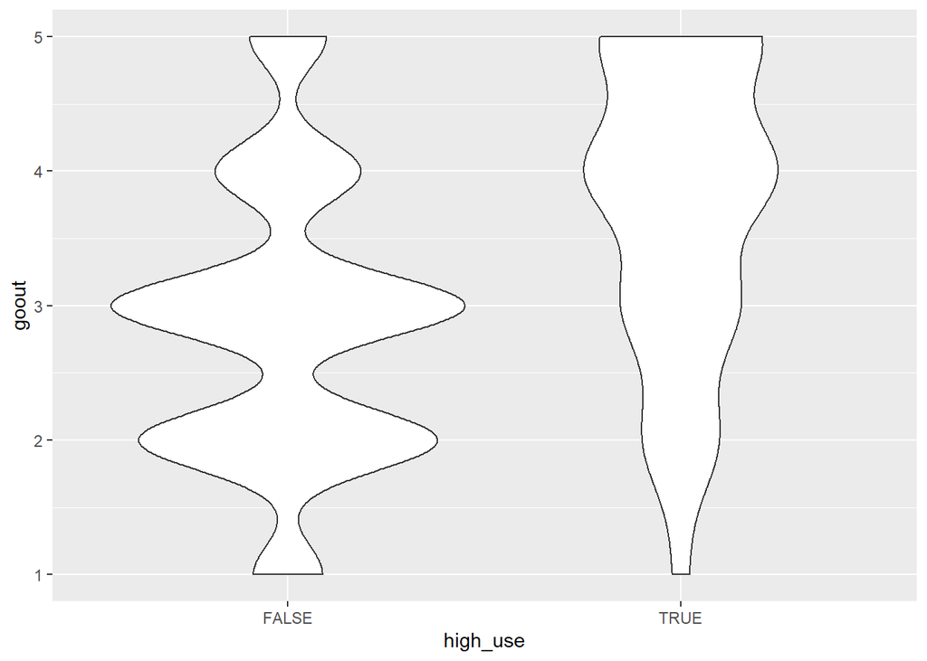

```r
ggplot(data=alc_use,
  aes(x=high_use,y=goout))+
  geom_violin()
```

```r
prop.table(table(alc_use$goout,alc_use$high_use),2)
```

```
##
##          FALSE       TRUE
##   1 0.07335907 0.02702703
##   2 0.31660232 0.13513514
##   3 0.37451737 0.20720721
##   4 0.15444015 0.34234234
##   5 0.08108108 0.28828829
```

```r
table(alc_use$sex,alc_use$high_use)
```

```
##
##     FALSE TRUE
##   F   154   41
##   M   105   70
```

```r
prop.table(table(alc_use$sex,alc_use$high_use),1)
```

```
##
##         FALSE      TRUE
##   F 0.7897436 0.2102564
##   M 0.6000000 0.4000000
```

```r
chisq.test(alc_use$sex,alc_use$high_use)
```

```
##
##  Pearson's Chi-squared test with Yates' continuity correction
##
## data:  alc_use$sex and alc_use$high_use
## X-squared = 14.921, df = 1, p-value = 0.0001121
```

Of these variables it is clear that going out has a positive association with high alcohol use, the distribution of going out is more pronounced towards the higher values (See the violin plot as well as the table of percentages). In addition, being a maleincreases the risk of high use: 40% of males and 20% of females are high users

### Logistic regression

My initial model consists of parental education, binary family relations indicator, continous going out variable and sex of the student:

```r
model_1 <-
  glm(high_use ~
        paredu + famrel_b + sex + goout,
      data=alc_use)
summary(model_1)
```

```
##
## Call:
## glm(formula = high_use ~ paredu + famrel_b + sex + goout, data = alc_use)
##
## Deviance Residuals:
##     Min       1Q   Median       3Q      Max
## -0.6052  -0.3183  -0.1386   0.3627   1.0720
##
## Coefficients:
##             Estimate Std. Error t value Pr(>|t|)
## (Intercept) -0.03823    0.09877  -0.387  0.69890
## paredu2     -0.12227    0.08427  -1.451  0.14764
## paredu3     -0.01163    0.08331  -0.140  0.88905
## paredu4     -0.08778    0.07931  -1.107  0.26910
## famrel_b    -0.16560    0.05059  -3.273  0.00117 **
## sexM         0.17968    0.04365   4.116 4.77e-05 ***
## goout        0.14342    0.01925   7.450 6.89e-13 ***
## ---
## Signif. codes:  0 '***' 0.001 '**' 0.01 '*' 0.05 '.' 0.1 ' ' 1
##
## (Dispersion parameter for gaussian family taken to be 0.1728196)
##
##     Null deviance: 77.700  on 369  degrees of freedom
## Residual deviance: 62.734  on 363  degrees of freedom
## AIC: 409.41
##
## Number of Fisher Scoring iterations: 2
```

The summary of the model indicates that parental education decreases the odds of high alcohol use in any of the higher categories of education when compared to the lowest level of parental education. However, the differences are not statistically significant. Being a male and going out a lot increase the odds of high alcohol use, and having good relations with family decreases the odds. Based on this initial model, I will leave parental education out of my final model.

```r
model_2 <-
  glm(high_use ~
        famrel_b + sex + goout,
      data=alc_use)

OR <- exp(coef(model_2))
CI <- exp(confint(model_2))

cbind(OR,CI)
```

```
##                    OR     2.5 %    97.5 %
## (Intercept) 0.8979596 0.7761920 1.0388300
## famrel_b    0.8533955 0.7728747 0.9423051
## sexM        1.1888255 1.0916995 1.2945926
## goout       1.1537940 1.1110075 1.1982283
```

In my final model, one step increase in going out increases the odds of high alcohol use by 15% (OR=1.15, 95% CI: 1.11, 1.20). Being a male increases the odds of high alcohol use by 19% (OR=1.19, 95% CI: 1.09, 1.29) and having good family relations decrease the odds by 15% (OR=0.85, 95% CI: 0.77,0.94). Since the confidence intervals do not include 1, all these association are statistically significant at 95% confidence level.

### Model predictions

```r
probs <- predict(model_2,
                 type = "response")
alc_use <-
  mutate(alc_use, probability = probs)

alc_use <-
  mutate(alc_use,
         predicted_high=probability>0.5)

#table
table(
  high_use = alc_use$high_use,
  prediction = alc_use$predicted_high)
```

```
##         prediction
## high_use FALSE TRUE
##    FALSE   253    6
##    TRUE     76   35
```

```r
#Proportions
table(
  high_use = alc_use$high_use,
  prediction = alc_use$predicted_high) %>%
  prop.table() %>% addmargins()
```

```
##         prediction
## high_use      FALSE       TRUE        Sum
##    FALSE 0.68378378 0.01621622 0.70000000
##    TRUE  0.20540541 0.09459459 0.30000000
##    Sum   0.88918919 0.11081081 1.00000000
```

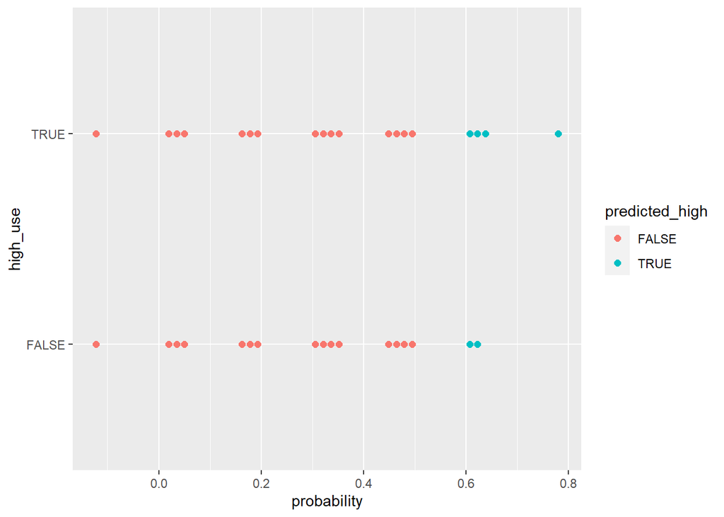

```r
#Graphical assessment
ggplot(alc_use,
       aes(x = probability,
           y = high_use,
           col=predicted_high)) +
  geom_point(size=2)
```

```r
# loss function (mean prediction error)
loss_func <- function(class, prob) {
  n_wrong <- abs(class - prob) > 0.5
  mean(n_wrong)
}

#average number of wrong predictions

loss_func(class = alc_use$high_use,
          prob = alc_use$probability)
```

```
## [1] 0.2216216
```

The total and average number of inaccurately classified individuals is around 22%.The model estimates that only 11% would be high users whereas in the observed data, 30% were identified as high users. On the other hand, almost all of the high use predictions were also true high users. Therefore, the estimates seem conservative, which is reassuring if any inference would be made. Erroneous TRUE predictions occured mostly for lower levels of predicted probabilities (see the Figure).

I am not sure how to compare this to a simple guessing strategy but I guess(!) that this would mean that if I simply try to guess one person’s alcohol consumption, there is a 50% chance I am wrong. Hence, I think the model is somewhat better than just guessing.

### 10-fold cross-validation

```r
library(boot)
cross_validation <-
  cv.glm(data = alc_use,
         cost = loss_func,
         glmfit = model_2, K = 10)

cross_validation$delta[1]
```

```
## [1] 0.2243243
```

Finally, I will try different including different sets of predictors and see what happens to the training and testing errors. I will start with a large model with 10 predictors, and move towards 1.

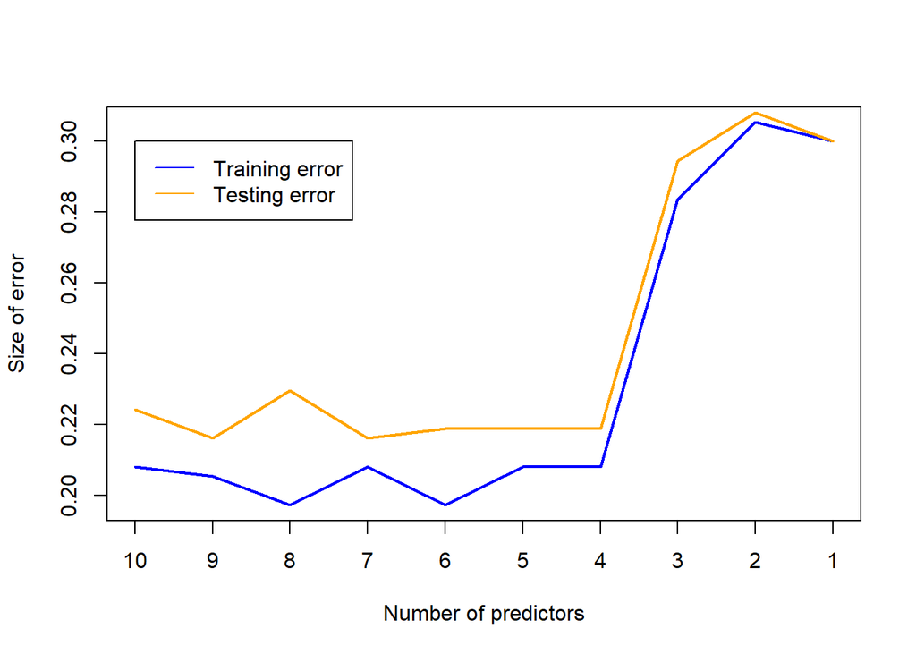

```r
m_1_formula <-
  as.formula('high_use~
             sex + age +
             famrel_b + goout +
             paredu + health +
             absences + romantic +
             studytime +
             school')
m_2_formula <-
  as.formula('high_use~
             sex + age +
             famrel_b + goout +
             paredu + health +
             absences + romantic +
             school')
m_3_formula <-
  as.formula('high_use~
             sex + age +
             famrel_b + goout +
             paredu + health +
             absences +
             school')
m_4_formula <-
  as.formula('high_use~
             sex + age +
             famrel_b + goout +
             paredu + health +
             school')
m_5_formula <-
  as.formula('high_use~
             sex + age +
             famrel_b + goout +
             paredu + school')
m_6_formula <-
  as.formula('high_use~
             sex + age +
             famrel_b + goout +
             school')
m_7_formula <-
  as.formula('high_use~
             sex + age +
             famrel_b + goout')
m_8_formula <-
  as.formula('high_use~
             sex + age +
             famrel_b')
m_9_formula <-
  as.formula('high_use~
             sex + age')
m_10_formula <-
  as.formula('high_use~
             sex')
library(purrr)
#is_formula(m_10_formula)

model_vector <- c(
  m_1_formula,
  m_2_formula,
  m_3_formula,
  m_4_formula,
  m_5_formula,
  m_6_formula,
  m_7_formula,
  m_8_formula,
  m_9_formula,
  m_10_formula)

#is_formula(model_vector[[1]])

error_mat <- matrix(NA,nrow=3,ncol=10)

for(i in 1:10){
  alc_temp <- alc_use
  current_model <- model_vector[[i]]

  current_glm <- glm(current_model,
                     family='binomial',
                     data=alc_temp)

  probs <- predict(current_glm,
                 type = "response")
alc_temp <-
  mutate(alc_temp, probability = probs)

alc_temp <-
  mutate(alc_temp,
         predicted_high=probability>0.5)

#average number of wrong predictions
error_mat[1,i] <-
  loss_func(class = alc_temp$high_use,
          prob = alc_temp$probability)

cross_validation <-
  cv.glm(data = alc_temp,
         cost = loss_func,
         glmfit = current_glm, K = 10)

error_mat[2,i] <-
  cross_validation$delta[1]

}

labels <- c("10","9","8","7","6",
     "5","4","3","2","1")

plot(error_mat[1,],type='l',
     col='blue',lwd=2,xaxt='n',
     xlab="Number of predictors",
     ylab="Size of error")
lines(error_mat[2,],col='orange',
      lwd=2)
axis(side=1,labels=labels,at=1:10)
legend(1,y=0.3,legend=c("Training error",
                "Testing error"),
       col=c('blue','orange'),
       lty=c(1,1))
```

Data reference: P. Cortez and A. Silva. Using Data Mining to Predict Secondary School Student Performance. In A. Brito and J. Teixeira Eds., Proceedings of 5th FUture BUsiness TEChnology Conference (FUBUTEC 2008) pp. 5-12, Porto, Portugal, April, 2008, EUROSIS, ISBN 978-9077381-39-7. https://archive.ics.uci.edu/ml/datasets/Student+Performance